# Risk Factor Analysis

## Outcome Variable

**Outcome Variable:** ever_co

## Predictor Variables

**Intervention Variable:** impfloor

**Adjustment Set:**

- arm
- sex
- W_mage
- meducyrs
- feducyrs
- hhwealth_quart
- hfoodsec
- W_mhtcm
- W_mwtkg
- W_mbmi
- W_nrooms
- W_nchldlt5
- W_parity
- impsan
- safeh20
- delta_W_mage
- delta_meducyrs
- delta_feducyrs
- delta_hhwealth_quart
- delta_hfoodsec
- delta_W_mhtcm
- delta_W_mwtkg
- delta_W_mbmi
- delta_W_nrooms
- delta_W_nchldlt5
- delta_W_parity
- delta_impsan
- delta_safeh20

## Stratifying Variables

The analysis was stratified on these variable(s):

- agecat
- studyid
- country

## Data Summary

| agecat | studyid | country | impfloor | ever_co | n_cell | n |
| --- | --- | --- | --- | --- | --- | --- |
| 0-24 months | CMC-V-BCS-2002 | INDIA | 1 | 0 | 198 | 261 |
| 0-24 months | CMC-V-BCS-2002 | INDIA | 1 | 1 | 63 | 261 |
| 0-24 months | CMC-V-BCS-2002 | INDIA | 0 | 0 | 0 | 261 |
| 0-24 months | CMC-V-BCS-2002 | INDIA | 0 | 1 | 0 | 261 |
| 0-24 months | CONTENT | PERU | 1 | 0 | 201 | 215 |
| 0-24 months | CONTENT | PERU | 1 | 1 | 0 | 215 |
| 0-24 months | CONTENT | PERU | 0 | 0 | 14 | 215 |
| 0-24 months | CONTENT | PERU | 0 | 1 | 0 | 215 |
| 0-24 months | GMS-Nepal | NEPAL | 1 | 0 | 73 | 536 |
| 0-24 months | GMS-Nepal | NEPAL | 1 | 1 | 26 | 536 |
| 0-24 months | GMS-Nepal | NEPAL | 0 | 0 | 304 | 536 |
| 0-24 months | GMS-Nepal | NEPAL | 0 | 1 | 133 | 536 |
| 0-24 months | IRC | INDIA | 1 | 0 | 253 | 306 |
| 0-24 months | IRC | INDIA | 1 | 1 | 53 | 306 |
| 0-24 months | IRC | INDIA | 0 | 0 | 0 | 306 |
| 0-24 months | IRC | INDIA | 0 | 1 | 0 | 306 |
| 0-24 months | JiVitA-3 | BANGLADESH | 1 | 0 | 2003 | 26854 |
| 0-24 months | JiVitA-3 | BANGLADESH | 1 | 1 | 115 | 26854 |
| 0-24 months | JiVitA-3 | BANGLADESH | 0 | 0 | 22468 | 26854 |
| 0-24 months | JiVitA-3 | BANGLADESH | 0 | 1 | 2268 | 26854 |
| 0-24 months | JiVitA-4 | BANGLADESH | 1 | 0 | 591 | 5425 |
| 0-24 months | JiVitA-4 | BANGLADESH | 1 | 1 | 57 | 5425 |
| 0-24 months | JiVitA-4 | BANGLADESH | 0 | 0 | 3958 | 5425 |
| 0-24 months | JiVitA-4 | BANGLADESH | 0 | 1 | 819 | 5425 |
| 0-24 months | MAL-ED | BANGLADESH | 1 | 0 | 189 | 242 |
| 0-24 months | MAL-ED | BANGLADESH | 1 | 1 | 34 | 242 |
| 0-24 months | MAL-ED | BANGLADESH | 0 | 0 | 14 | 242 |
| 0-24 months | MAL-ED | BANGLADESH | 0 | 1 | 5 | 242 |
| 0-24 months | MAL-ED | BRAZIL | 1 | 0 | 205 | 210 |
| 0-24 months | MAL-ED | BRAZIL | 1 | 1 | 3 | 210 |

[output cut: 162 more lines]

The following strata were considered:

- agecat: 0-24 months, studyid: CMC-V-BCS-2002, country: INDIA
- agecat: 0-24 months, studyid: CONTENT, country: PERU
- agecat: 0-24 months, studyid: GMS-Nepal, country: NEPAL
- agecat: 0-24 months, studyid: IRC, country: INDIA
- agecat: 0-24 months, studyid: JiVitA-3, country: BANGLADESH
- agecat: 0-24 months, studyid: JiVitA-4, country: BANGLADESH
- agecat: 0-24 months, studyid: MAL-ED, country: BANGLADESH
- agecat: 0-24 months, studyid: MAL-ED, country: BRAZIL
- agecat: 0-24 months, studyid: MAL-ED, country: INDIA
- agecat: 0-24 months, studyid: MAL-ED, country: NEPAL
- agecat: 0-24 months, studyid: MAL-ED, country: PERU
- agecat: 0-24 months, studyid: MAL-ED, country: SOUTH AFRICA
- agecat: 0-24 months, studyid: MAL-ED, country: TANZANIA, UNITED REPUBLIC OF
- agecat: 0-24 months, studyid: NIH-Birth, country: BANGLADESH
- agecat: 0-24 months, studyid: NIH-Crypto, country: BANGLADESH
- agecat: 0-24 months, studyid: PROVIDE, country: BANGLADESH
- agecat: 0-6 months, studyid: CMC-V-BCS-2002, country: INDIA
- agecat: 0-6 months, studyid: CONTENT, country: PERU
- agecat: 0-6 months, studyid: GMS-Nepal, country: NEPAL
- agecat: 0-6 months, studyid: IRC, country: INDIA
- agecat: 0-6 months, studyid: JiVitA-3, country: BANGLADESH
- agecat: 0-6 months, studyid: JiVitA-4, country: BANGLADESH
- agecat: 0-6 months, studyid: MAL-ED, country: BANGLADESH
- agecat: 0-6 months, studyid: MAL-ED, country: BRAZIL
- agecat: 0-6 months, studyid: MAL-ED, country: INDIA
- agecat: 0-6 months, studyid: MAL-ED, country: NEPAL
- agecat: 0-6 months, studyid: MAL-ED, country: PERU
- agecat: 0-6 months, studyid: MAL-ED, country: SOUTH AFRICA
- agecat: 0-6 months, studyid: MAL-ED, country: TANZANIA, UNITED REPUBLIC OF
- agecat: 0-6 months, studyid: NIH-Birth, country: BANGLADESH
- agecat: 0-6 months, studyid: NIH-Crypto, country: BANGLADESH
- agecat: 0-6 months, studyid: PROVIDE, country: BANGLADESH
- agecat: 6-24 months, studyid: CMC-V-BCS-2002, country: INDIA
- agecat: 6-24 months, studyid: CONTENT, country: PERU
- agecat: 6-24 months, studyid: GMS-Nepal, country: NEPAL
- agecat: 6-24 months, studyid: IRC, country: INDIA
- agecat: 6-24 months, studyid: JiVitA-3, country: BANGLADESH
- agecat: 6-24 months, studyid: JiVitA-4, country: BANGLADESH
- agecat: 6-24 months, studyid: MAL-ED, country: BANGLADESH
- agecat: 6-24 months, studyid: MAL-ED, country: BRAZIL
- agecat: 6-24 months, studyid: MAL-ED, country: INDIA
- agecat: 6-24 months, studyid: MAL-ED, country: NEPAL
- agecat: 6-24 months, studyid: MAL-ED, country: PERU
- agecat: 6-24 months, studyid: MAL-ED, country: SOUTH AFRICA
- agecat: 6-24 months, studyid: MAL-ED, country: TANZANIA, UNITED REPUBLIC OF
- agecat: 6-24 months, studyid: NIH-Birth, country: BANGLADESH
- agecat: 6-24 months, studyid: NIH-Crypto, country: BANGLADESH
- agecat: 6-24 months, studyid: PROVIDE, country: BANGLADESH

### Dropped Strata

Some strata were dropped due to rare outcomes:

- agecat: 0-24 months, studyid: CMC-V-BCS-2002, country: INDIA
- agecat: 0-24 months, studyid: CONTENT, country: PERU
- agecat: 0-24 months, studyid: IRC, country: INDIA
- agecat: 0-24 months, studyid: MAL-ED, country: BRAZIL
- agecat: 0-24 months, studyid: MAL-ED, country: PERU
- agecat: 0-24 months, studyid: MAL-ED, country: SOUTH AFRICA
- agecat: 0-24 months, studyid: MAL-ED, country: TANZANIA, UNITED REPUBLIC OF
- agecat: 0-6 months, studyid: CMC-V-BCS-2002, country: INDIA
- agecat: 0-6 months, studyid: CONTENT, country: PERU
- agecat: 0-6 months, studyid: IRC, country: INDIA
- agecat: 0-6 months, studyid: MAL-ED, country: BANGLADESH
- agecat: 0-6 months, studyid: MAL-ED, country: BRAZIL
- agecat: 0-6 months, studyid: MAL-ED, country: INDIA
- agecat: 0-6 months, studyid: MAL-ED, country: NEPAL
- agecat: 0-6 months, studyid: MAL-ED, country: PERU
- agecat: 0-6 months, studyid: MAL-ED, country: SOUTH AFRICA
- agecat: 0-6 months, studyid: MAL-ED, country: TANZANIA, UNITED REPUBLIC OF
- agecat: 0-6 months, studyid: NIH-Crypto, country: BANGLADESH
- agecat: 6-24 months, studyid: CMC-V-BCS-2002, country: INDIA
- agecat: 6-24 months, studyid: CONTENT, country: PERU
- agecat: 6-24 months, studyid: IRC, country: INDIA
- agecat: 6-24 months, studyid: MAL-ED, country: BANGLADESH
- agecat: 6-24 months, studyid: MAL-ED, country: BRAZIL
- agecat: 6-24 months, studyid: MAL-ED, country: PERU
- agecat: 6-24 months, studyid: MAL-ED, country: SOUTH AFRICA
- agecat: 6-24 months, studyid: MAL-ED, country: TANZANIA, UNITED REPUBLIC OF

## Methods Detail

We’re interested in the causal parameters $E[Y_a]$ for all values of $a \in \mathcal{A}$. These parameters represent the mean outcome if, possibly contrary to fact, we intervened to set all units to have $A=a$. Under the randomization and positivity assumptions, these are identified by the statistical parameters $\psi_a=E_W[E_{Y|A,W}(Y|A=a,W)]$. In addition, we’re interested in the mean of $Y$, $E[Y]$ under no intervention (the observed mean). We will estimate these parameters by using SuperLearner to fit the relevant likelihood factors – $E_{Y|A,W}(Y|A=a,W)$ and $p(A=a|W)$, and then updating our likelihood fit using a joint TMLE.

For unadjusted analyses ($W=\{\}$), initial likelihoods were estimated using Lrnr_glm to estimate the simple $E(Y|A)$ and Lrnr_mean to estimate $p(A)$. For adjusted analyses, a small library containing Lrnr_glmnet, Lrnr_xgboost, and Lrnr_mean was used.

Having estimated these parameters, we will then use the delta method to estimate relative risks and attributable risks relative to a prespecified baseline level of $A$.

# Results Detail

## Results Plots

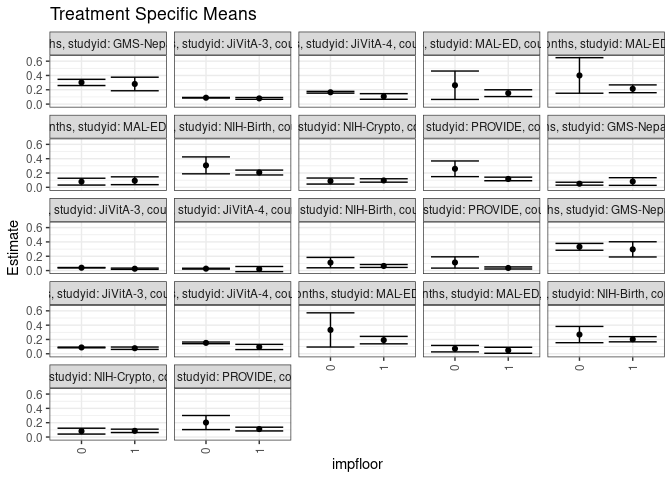

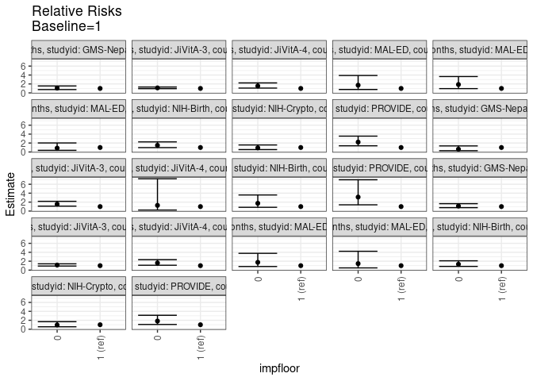

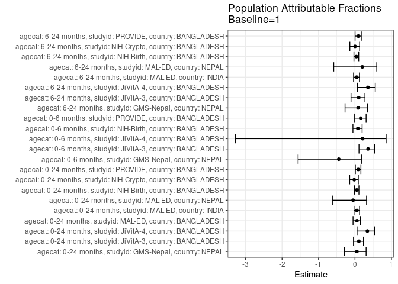

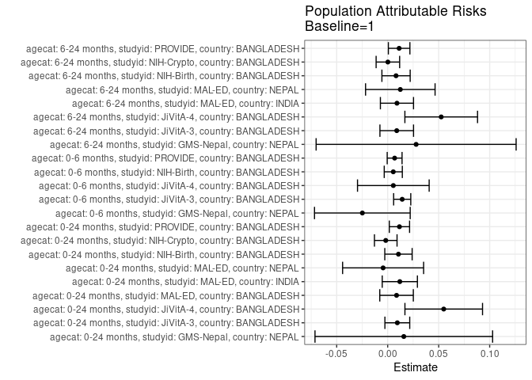

## Results Table

### Parameter: TSM

| agecat | studyid | country | intervention_level | baseline_level | estimate | ci_lower | ci_upper |
| --- | --- | --- | --- | --- | --- | --- | --- |
| 0-24 months | GMS-Nepal | NEPAL | 1 | NA | 0.2808408 | 0.1861052 | 0.3755765 |
| 0-24 months | GMS-Nepal | NEPAL | 0 | NA | 0.3024995 | 0.2590906 | 0.3459084 |
| 0-24 months | JiVitA-3 | BANGLADESH | 1 | NA | 0.0792937 | 0.0669004 | 0.0916870 |
| 0-24 months | JiVitA-3 | BANGLADESH | 0 | NA | 0.0888129 | 0.0847817 | 0.0928441 |
| 0-24 months | JiVitA-4 | BANGLADESH | 1 | NA | 0.1065249 | 0.0673847 | 0.1456650 |
| 0-24 months | JiVitA-4 | BANGLADESH | 0 | NA | 0.1651079 | 0.1531066 | 0.1771093 |
| 0-24 months | MAL-ED | BANGLADESH | 1 | NA | 0.1524664 | 0.1051882 | 0.1997445 |
| 0-24 months | MAL-ED | BANGLADESH | 0 | NA | 0.2631579 | 0.0647468 | 0.4615690 |
| 0-24 months | MAL-ED | INDIA | 1 | NA | 0.2136364 | 0.1593598 | 0.2679129 |
| 0-24 months | MAL-ED | INDIA | 0 | NA | 0.4000000 | 0.1515528 | 0.6484472 |
| 0-24 months | MAL-ED | NEPAL | 1 | NA | 0.0918224 | 0.0369271 | 0.1467177 |
| 0-24 months | MAL-ED | NEPAL | 0 | NA | 0.0790269 | 0.0314219 | 0.1266318 |
| 0-24 months | NIH-Birth | BANGLADESH | 1 | NA | 0.2068235 | 0.1727892 | 0.2408577 |
| 0-24 months | NIH-Birth | BANGLADESH | 0 | NA | 0.3065820 | 0.1881689 | 0.4249951 |
| 0-24 months | NIH-Crypto | BANGLADESH | 1 | NA | 0.0955709 | 0.0716498 | 0.1194920 |
| 0-24 months | NIH-Crypto | BANGLADESH | 0 | NA | 0.0874659 | 0.0454994 | 0.1294325 |
| 0-24 months | PROVIDE | BANGLADESH | 1 | NA | 0.1170442 | 0.0920817 | 0.1420067 |
| 0-24 months | PROVIDE | BANGLADESH | 0 | NA | 0.2586656 | 0.1489621 | 0.3683692 |
| 0-6 months | GMS-Nepal | NEPAL | 1 | NA | 0.0808081 | 0.0270719 | 0.1345442 |
| 0-6 months | GMS-Nepal | NEPAL | 0 | NA | 0.0503432 | 0.0298237 | 0.0708628 |
| 0-6 months | JiVitA-3 | BANGLADESH | 1 | NA | 0.0253988 | 0.0169229 | 0.0338747 |
| 0-6 months | JiVitA-3 | BANGLADESH | 0 | NA | 0.0393462 | 0.0367384 | 0.0419541 |
| 0-6 months | JiVitA-4 | BANGLADESH | 1 | NA | 0.0208406 | -0.0151018 | 0.0567830 |
| 0-6 months | JiVitA-4 | BANGLADESH | 0 | NA | 0.0264956 | 0.0207351 | 0.0322562 |
| 0-6 months | NIH-Birth | BANGLADESH | 1 | NA | 0.0639854 | 0.0434602 | 0.0845106 |
| 0-6 months | NIH-Birth | BANGLADESH | 0 | NA | 0.1111111 | 0.0384611 | 0.1837611 |
| 0-6 months | PROVIDE | BANGLADESH | 1 | NA | 0.0360502 | 0.0215748 | 0.0505255 |
| 0-6 months | PROVIDE | BANGLADESH | 0 | NA | 0.1129032 | 0.0340714 | 0.1917350 |
| 6-24 months | GMS-Nepal | NEPAL | 1 | NA | 0.2960900 | 0.1898066 | 0.4023734 |
| 6-24 months | GMS-Nepal | NEPAL | 0 | NA | 0.3317807 | 0.2841790 | 0.3793823 |
| 6-24 months | JiVitA-3 | BANGLADESH | 1 | NA | 0.0777805 | 0.0610565 | 0.0945046 |
| 6-24 months | JiVitA-3 | BANGLADESH | 0 | NA | 0.0884010 | 0.0834880 | 0.0933141 |
| 6-24 months | JiVitA-4 | BANGLADESH | 1 | NA | 0.0952788 | 0.0588585 | 0.1316991 |
| 6-24 months | JiVitA-4 | BANGLADESH | 0 | NA | 0.1524279 | 0.1409561 | 0.1638997 |
| 6-24 months | MAL-ED | INDIA | 1 | NA | 0.1909091 | 0.1388646 | 0.2429536 |
| 6-24 months | MAL-ED | INDIA | 0 | NA | 0.3333333 | 0.0942649 | 0.5724018 |
| 6-24 months | MAL-ED | NEPAL | 1 | NA | 0.0490196 | 0.0070270 | 0.0910122 |
| 6-24 months | MAL-ED | NEPAL | 0 | NA | 0.0714286 | 0.0263613 | 0.1164958 |
| 6-24 months | NIH-Birth | BANGLADESH | 1 | NA | 0.2033139 | 0.1670937 | 0.2395341 |
| 6-24 months | NIH-Birth | BANGLADESH | 0 | NA | 0.2684614 | 0.1546038 | 0.3823190 |
| 6-24 months | NIH-Crypto | BANGLADESH | 1 | NA | 0.0861086 | 0.0626820 | 0.1095353 |
| 6-24 months | NIH-Crypto | BANGLADESH | 0 | NA | 0.0820805 | 0.0410140 | 0.1231470 |
| 6-24 months | PROVIDE | BANGLADESH | 1 | NA | 0.1109288 | 0.0848786 | 0.1369790 |
| 6-24 months | PROVIDE | BANGLADESH | 0 | NA | 0.2020469 | 0.1035218 | 0.3005721 |

### Parameter: E(Y)

| agecat | studyid | country | intervention_level | baseline_level | estimate | ci_lower | ci_upper |
| --- | --- | --- | --- | --- | --- | --- | --- |
| 0-24 months | GMS-Nepal | NEPAL | NA | NA | 0.2966418 | 0.2579360 | 0.3353476 |
| 0-24 months | JiVitA-3 | BANGLADESH | NA | NA | 0.0887391 | 0.0848621 | 0.0926161 |
| 0-24 months | JiVitA-4 | BANGLADESH | NA | NA | 0.1614747 | 0.1501435 | 0.1728058 |
| 0-24 months | MAL-ED | BANGLADESH | NA | NA | 0.1611570 | 0.1147371 | 0.2075770 |
| 0-24 months | MAL-ED | INDIA | NA | NA | 0.2255319 | 0.1719836 | 0.2790802 |
| 0-24 months | MAL-ED | NEPAL | NA | NA | 0.0873362 | 0.0506897 | 0.1239828 |
| 0-24 months | NIH-Birth | BANGLADESH | NA | NA | 0.2173913 | 0.1849240 | 0.2498586 |
| 0-24 months | NIH-Crypto | BANGLADESH | NA | NA | 0.0936675 | 0.0729118 | 0.1144233 |
| 0-24 months | PROVIDE | BANGLADESH | NA | NA | 0.1285714 | 0.1037574 | 0.1533855 |
| 0-6 months | GMS-Nepal | NEPAL | NA | NA | 0.0559701 | 0.0364922 | 0.0754481 |
| 0-6 months | JiVitA-3 | BANGLADESH | NA | NA | 0.0396306 | 0.0371318 | 0.0421294 |
| 0-6 months | JiVitA-4 | BANGLADESH | NA | NA | 0.0263831 | 0.0210411 | 0.0317252 |
| 0-6 months | NIH-Birth | BANGLADESH | NA | NA | 0.0694669 | 0.0494218 | 0.0895120 |
| 0-6 months | PROVIDE | BANGLADESH | NA | NA | 0.0428571 | 0.0278427 | 0.0578716 |
| 6-24 months | GMS-Nepal | NEPAL | NA | NA | 0.3239741 | 0.2813000 | 0.3666481 |
| 6-24 months | JiVitA-3 | BANGLADESH | NA | NA | 0.0866539 | 0.0820272 | 0.0912806 |
| 6-24 months | JiVitA-4 | BANGLADESH | NA | NA | 0.1477587 | 0.1371623 | 0.1583552 |
| 6-24 months | MAL-ED | INDIA | NA | NA | 0.2000000 | 0.1487493 | 0.2512507 |
| 6-24 months | MAL-ED | NEPAL | NA | NA | 0.0614035 | 0.0301736 | 0.0926335 |
| 6-24 months | NIH-Birth | BANGLADESH | NA | NA | 0.2115028 | 0.1769952 | 0.2460104 |
| 6-24 months | NIH-Crypto | BANGLADESH | NA | NA | 0.0863014 | 0.0659171 | 0.1066856 |
| 6-24 months | PROVIDE | BANGLADESH | NA | NA | 0.1221498 | 0.0962275 | 0.1480722 |

### Parameter: RR

| agecat | studyid | country | intervention_level | baseline_level | estimate | ci_lower | ci_upper |
| --- | --- | --- | --- | --- | --- | --- | --- |
| 0-24 months | GMS-Nepal | NEPAL | 1 | 1 | 1.0000000 | 1.0000000 | 1.000000 |
| 0-24 months | GMS-Nepal | NEPAL | 0 | 1 | 1.0771210 | 0.7469458 | 1.553245 |
| 0-24 months | JiVitA-3 | BANGLADESH | 1 | 1 | 1.0000000 | 1.0000000 | 1.000000 |
| 0-24 months | JiVitA-3 | BANGLADESH | 0 | 1 | 1.1200499 | 0.9540711 | 1.314904 |
| 0-24 months | JiVitA-4 | BANGLADESH | 1 | 1 | 1.0000000 | 1.0000000 | 1.000000 |
| 0-24 months | JiVitA-4 | BANGLADESH | 0 | 1 | 1.5499474 | 1.0753398 | 2.234026 |
| 0-24 months | MAL-ED | BANGLADESH | 1 | 1 | 1.0000000 | 1.0000000 | 1.000000 |
| 0-24 months | MAL-ED | BANGLADESH | 0 | 1 | 1.7260062 | 0.7638160 | 3.900281 |
| 0-24 months | MAL-ED | INDIA | 1 | 1 | 1.0000000 | 1.0000000 | 1.000000 |
| 0-24 months | MAL-ED | INDIA | 0 | 1 | 1.8723404 | 0.9570686 | 3.662913 |
| 0-24 months | MAL-ED | NEPAL | 1 | 1 | 1.0000000 | 1.0000000 | 1.000000 |
| 0-24 months | MAL-ED | NEPAL | 0 | 1 | 0.8606492 | 0.3673114 | 2.016591 |
| 0-24 months | NIH-Birth | BANGLADESH | 1 | 1 | 1.0000000 | 1.0000000 | 1.000000 |
| 0-24 months | NIH-Birth | BANGLADESH | 0 | 1 | 1.4823367 | 0.9743929 | 2.255068 |
| 0-24 months | NIH-Crypto | BANGLADESH | 1 | 1 | 1.0000000 | 1.0000000 | 1.000000 |
| 0-24 months | NIH-Crypto | BANGLADESH | 0 | 1 | 0.9151943 | 0.5328365 | 1.571928 |
| 0-24 months | PROVIDE | BANGLADESH | 1 | 1 | 1.0000000 | 1.0000000 | 1.000000 |
| 0-24 months | PROVIDE | BANGLADESH | 0 | 1 | 2.2099833 | 1.3760641 | 3.549272 |
| 0-6 months | GMS-Nepal | NEPAL | 1 | 1 | 1.0000000 | 1.0000000 | 1.000000 |
| 0-6 months | GMS-Nepal | NEPAL | 0 | 1 | 0.6229977 | 0.2855976 | 1.358996 |
| 0-6 months | JiVitA-3 | BANGLADESH | 1 | 1 | 1.0000000 | 1.0000000 | 1.000000 |
| 0-6 months | JiVitA-3 | BANGLADESH | 0 | 1 | 1.5491390 | 1.1032009 | 2.175335 |
| 0-6 months | JiVitA-4 | BANGLADESH | 1 | 1 | 1.0000000 | 1.0000000 | 1.000000 |
| 0-6 months | JiVitA-4 | BANGLADESH | 0 | 1 | 1.2713468 | 0.2231843 | 7.242100 |
| 0-6 months | NIH-Birth | BANGLADESH | 1 | 1 | 1.0000000 | 1.0000000 | 1.000000 |
| 0-6 months | NIH-Birth | BANGLADESH | 0 | 1 | 1.7365079 | 0.8382638 | 3.597268 |
| 0-6 months | PROVIDE | BANGLADESH | 1 | 1 | 1.0000000 | 1.0000000 | 1.000000 |
| 0-6 months | PROVIDE | BANGLADESH | 0 | 1 | 3.1318373 | 1.3995795 | 7.008108 |
| 6-24 months | GMS-Nepal | NEPAL | 1 | 1 | 1.0000000 | 1.0000000 | 1.000000 |
| 6-24 months | GMS-Nepal | NEPAL | 0 | 1 | 1.1205400 | 0.7612919 | 1.649315 |
| 6-24 months | JiVitA-3 | BANGLADESH | 1 | 1 | 1.0000000 | 1.0000000 | 1.000000 |
| 6-24 months | JiVitA-3 | BANGLADESH | 0 | 1 | 1.1365444 | 0.9122129 | 1.416044 |
| 6-24 months | JiVitA-4 | BANGLADESH | 1 | 1 | 1.0000000 | 1.0000000 | 1.000000 |
| 6-24 months | JiVitA-4 | BANGLADESH | 0 | 1 | 1.5998091 | 1.0922996 | 2.343120 |
| 6-24 months | MAL-ED | INDIA | 1 | 1 | 1.0000000 | 1.0000000 | 1.000000 |
| 6-24 months | MAL-ED | INDIA | 0 | 1 | 1.7460317 | 0.8106464 | 3.760736 |
| 6-24 months | MAL-ED | NEPAL | 1 | 1 | 1.0000000 | 1.0000000 | 1.000000 |
| 6-24 months | MAL-ED | NEPAL | 0 | 1 | 1.4571429 | 0.5028581 | 4.222395 |
| 6-24 months | NIH-Birth | BANGLADESH | 1 | 1 | 1.0000000 | 1.0000000 | 1.000000 |
| 6-24 months | NIH-Birth | BANGLADESH | 0 | 1 | 1.3204280 | 0.8344703 | 2.089386 |
| 6-24 months | NIH-Crypto | BANGLADESH | 1 | 1 | 1.0000000 | 1.0000000 | 1.000000 |
| 6-24 months | NIH-Crypto | BANGLADESH | 0 | 1 | 0.9532199 | 0.5396571 | 1.683714 |
| 6-24 months | PROVIDE | BANGLADESH | 1 | 1 | 1.0000000 | 1.0000000 | 1.000000 |
| 6-24 months | PROVIDE | BANGLADESH | 0 | 1 | 1.8214115 | 1.0630322 | 3.120827 |

### Parameter: PAR

| agecat | studyid | country | intervention_level | baseline_level | estimate | ci_lower | ci_upper |
| --- | --- | --- | --- | --- | --- | --- | --- |
| 0-24 months | GMS-Nepal | NEPAL | 1 | NA | 0.0158010 | -0.0712610 | 0.1028630 |
| 0-24 months | JiVitA-3 | BANGLADESH | 1 | NA | 0.0094454 | -0.0027213 | 0.0216122 |
| 0-24 months | JiVitA-4 | BANGLADESH | 1 | NA | 0.0549498 | 0.0169062 | 0.0929933 |
| 0-24 months | MAL-ED | BANGLADESH | 1 | NA | 0.0086907 | -0.0077585 | 0.0251398 |
| 0-24 months | MAL-ED | INDIA | 1 | NA | 0.0118956 | -0.0053544 | 0.0291455 |
| 0-24 months | MAL-ED | NEPAL | 1 | NA | -0.0044861 | -0.0441958 | 0.0352236 |
| 0-24 months | NIH-Birth | BANGLADESH | 1 | NA | 0.0105678 | -0.0028361 | 0.0239718 |
| 0-24 months | NIH-Crypto | BANGLADESH | 1 | NA | -0.0019034 | -0.0129790 | 0.0091723 |
| 0-24 months | PROVIDE | BANGLADESH | 1 | NA | 0.0115273 | 0.0015911 | 0.0214634 |
| 0-6 months | GMS-Nepal | NEPAL | 1 | NA | -0.0248379 | -0.0717451 | 0.0220693 |
| 0-6 months | JiVitA-3 | BANGLADESH | 1 | NA | 0.0142318 | 0.0058324 | 0.0226313 |
| 0-6 months | JiVitA-4 | BANGLADESH | 1 | NA | 0.0055426 | -0.0295789 | 0.0406640 |
| 0-6 months | NIH-Birth | BANGLADESH | 1 | NA | 0.0054815 | -0.0033801 | 0.0143431 |
| 0-6 months | PROVIDE | BANGLADESH | 1 | NA | 0.0068070 | -0.0004742 | 0.0140882 |
| 6-24 months | GMS-Nepal | NEPAL | 1 | NA | 0.0278841 | -0.0701615 | 0.1259297 |
| 6-24 months | JiVitA-3 | BANGLADESH | 1 | NA | 0.0088734 | -0.0076012 | 0.0253480 |
| 6-24 months | JiVitA-4 | BANGLADESH | 1 | NA | 0.0524799 | 0.0168607 | 0.0880991 |
| 6-24 months | MAL-ED | INDIA | 1 | NA | 0.0090909 | -0.0071508 | 0.0253326 |
| 6-24 months | MAL-ED | NEPAL | 1 | NA | 0.0123839 | -0.0216885 | 0.0464563 |
| 6-24 months | NIH-Birth | BANGLADESH | 1 | NA | 0.0081889 | -0.0056700 | 0.0220477 |
| 6-24 months | NIH-Crypto | BANGLADESH | 1 | NA | 0.0001927 | -0.0113365 | 0.0117219 |
| 6-24 months | PROVIDE | BANGLADESH | 1 | NA | 0.0112211 | 0.0006689 | 0.0217732 |

### Parameter: PAF

| agecat | studyid | country | intervention_level | baseline_level | estimate | ci_lower | ci_upper |
| --- | --- | --- | --- | --- | --- | --- | --- |
| 0-24 months | GMS-Nepal | NEPAL | 1 | NA | 0.0532662 | -0.2907740 | 0.3056067 |
| 0-24 months | JiVitA-3 | BANGLADESH | 1 | NA | 0.1064405 | -0.0412921 | 0.2332137 |
| 0-24 months | JiVitA-4 | BANGLADESH | 1 | NA | 0.3402998 | 0.0571418 | 0.5384201 |
| 0-24 months | MAL-ED | BANGLADESH | 1 | NA | 0.0539266 | -0.0530109 | 0.1500043 |
| 0-24 months | MAL-ED | INDIA | 1 | NA | 0.0527444 | -0.0264141 | 0.1257982 |
| 0-24 months | MAL-ED | NEPAL | 1 | NA | -0.0513662 | -0.6199230 | 0.3176399 |
| 0-24 months | NIH-Birth | BANGLADESH | 1 | NA | 0.0486121 | -0.0148723 | 0.1081252 |
| 0-24 months | NIH-Crypto | BANGLADESH | 1 | NA | -0.0203203 | -0.1455793 | 0.0912427 |
| 0-24 months | PROVIDE | BANGLADESH | 1 | NA | 0.0896565 | 0.0103910 | 0.1625731 |
| 0-6 months | GMS-Nepal | NEPAL | 1 | NA | -0.4437710 | -1.5587230 | 0.1853457 |
| 0-6 months | JiVitA-3 | BANGLADESH | 1 | NA | 0.3591120 | 0.1099584 | 0.5385189 |
| 0-6 months | JiVitA-4 | BANGLADESH | 1 | NA | 0.2100795 | -3.2825514 | 0.8542985 |
| 0-6 months | NIH-Birth | BANGLADESH | 1 | NA | 0.0789082 | -0.0558885 | 0.1964965 |
| 0-6 months | PROVIDE | BANGLADESH | 1 | NA | 0.1588297 | -0.0189113 | 0.3055651 |
| 6-24 months | GMS-Nepal | NEPAL | 1 | NA | 0.0860689 | -0.2727276 | 0.3437165 |
| 6-24 months | JiVitA-3 | BANGLADESH | 1 | NA | 0.1024004 | -0.1088683 | 0.2734168 |
| 6-24 months | JiVitA-4 | BANGLADESH | 1 | NA | 0.3551730 | 0.0635889 | 0.5559622 |
| 6-24 months | MAL-ED | INDIA | 1 | NA | 0.0454545 | -0.0388318 | 0.1229023 |
| 6-24 months | MAL-ED | NEPAL | 1 | NA | 0.2016807 | -0.5826684 | 0.5973170 |
| 6-24 months | NIH-Birth | BANGLADESH | 1 | NA | 0.0387175 | -0.0289173 | 0.1019063 |
| 6-24 months | NIH-Crypto | BANGLADESH | 1 | NA | 0.0022331 | -0.1407173 | 0.1272696 |
| 6-24 months | PROVIDE | BANGLADESH | 1 | NA | 0.0918632 | 0.0029322 | 0.1728622 |